# AFDMD-111 Estadística

Distribuciones de probabilidad

## Distribuciones discretas de probabilidad

Las distribuciones probabilidad se pueden clasificar en dos tipos importantes:

- Distribuciones discretas.
- Distribuciones continuas.

### Distribución de Bernoulli

Entre las distribuciones de probabilidad discretas podemos mencionar a la distribución de Bernoulli, la cual tiene la siguiente forma matemática:

$$p(k) = p^k(1-p)^{1-k}, \; \mbox{para} \; k\in (0,1)$$

En `R`, podemos simular muestras de la distribución de Bernoulli mediante el comando:

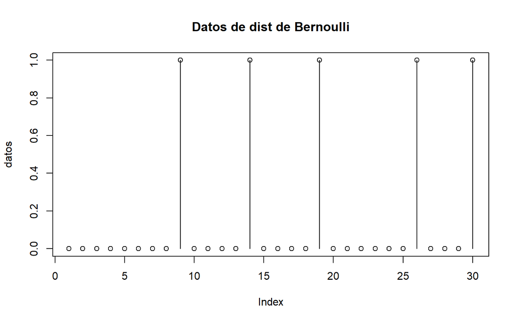

```r
# Sacamos una muestra de 30 datos Bernoulli y graficamos
datos <- rbinom(n=30, size=1, prob=0.3)
plot(datos, type="h", main="Datos de dist de Bernoulli")
points(datos)
```

En este caso size representa a $n$ que es igual a $1$. Otra distribución discreta importante es la Binomial (la de Bernoulli es un caso especial de ésta).

### Distribución Binomial

La distribución binomial representa el número de éxitos en $n$ intentos, mientras que la de Bernoulli, representa éxito o fracaso, la fórmula que representa a la distribución Binomial está dada por:

$$Pr(X=k) = {n\choose k} p^k(1-p)^{n-k}$$
En `R` podemos simular a la distribución Binomial como:

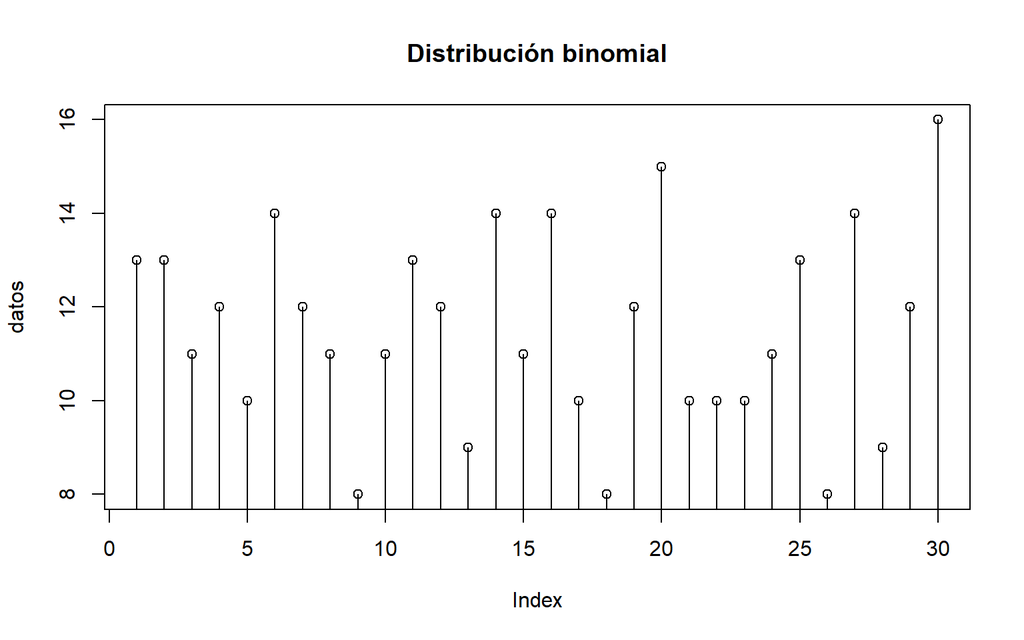

```r
datos <- rbinom(30, size=20, prob=0.6)
plot(datos, type="h", main= "Distribución binomial")
points(datos)
```

y si hacemos la probabilidad más pequeña ($p=0.1$), tenemos;

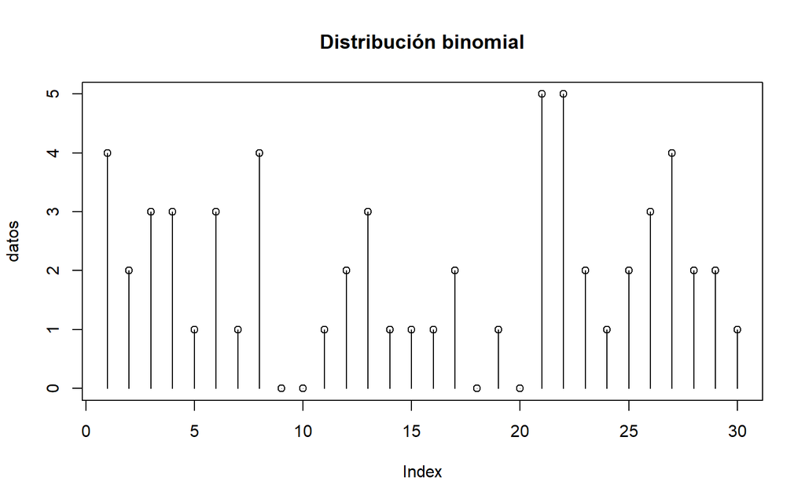

```r
datos <- rbinom(30, size=20, prob=0.1)
plot(datos, type="h", main= "Distribución binomial")
points(datos)
```

### Tarea

Investigar las siguiente distribuciones discretas y verificar cómo se pueden generar en `R` (Nota: no es necesario generarlos en `R`, es opcional).

- Distribución de Poison.
- Distribución Geométrica.
- Distribución Uniforme discreta.
- Distribución Hipergeométrica.

## Distribusion de Poison

La distribución de Poisson es una distribución de probabilidad discreta que modela el número de eventos que ocurren en un intervalo fijo de tiempo o espacio, bajo la suposición de que estos eventos ocurren con una tasa constante y de manera independiente. En R Studio, puedes utilizar funciones específicas para trabajar con la distribución de Poisson.

En R para la distribución de Poisson es dpois(), y se utiliza para calcular la función de masa de probabilidad (PMF). Además, puedes usar ppois() para calcular la función de distribución acumulativa (CDF), rpois() para generar números aleatorios que sigan una distribución de Poisson y qpois() para obtener los cuantiles. Por ejemplo.

```r
# Parámetros de la distribución de Poisson
tasa_promedio <- 2  # Tasa promedio de ocurrencia de eventos
num_eventos <- 3    # Número de eventos que queremos modelar

# PMF: Probabilidad de que ocurran num_eventos eventos
probabilidad <- dpois(num_eventos, lambda = tasa_promedio)

# CDF: Probabilidad acumulativa de que ocurran hasta num_eventos eventos
prob_acumulativa <- ppois(num_eventos, lambda = tasa_promedio)

# Generar números aleatorios que sigan una distribución de Poisson
num_aleatorios <- rpois(n = 5, lambda = tasa_promedio)

# Calcular cuantiles de la distribución de Poisson
cuantil_95 <- qpois(0.95, lambda = tasa_promedio)

# Imprimir resultados
cat("Probabilidad de", num_eventos, "eventos:", probabilidad, "\n")
```

```
## Probabilidad de 3 eventos: 0.180447
```

```r
cat("Probabilidad acumulativa hasta", num_eventos, "eventos:", prob_acumulativa, "\n")
```

```
## Probabilidad acumulativa hasta 3 eventos: 0.8571235
```

```r
cat("Números aleatorios generados:", num_aleatorios, "\n")
```

```
## Números aleatorios generados: 3 2 3 5 5
```

```r
cat("Cuantil al 95%:", cuantil_95, "\n")
```

```
## Cuantil al 95%: 5
```

## Distribución Geométrica.

la distribución geométrica modela el número de ensayos o experimentos independientes necesarios para obtener el primer éxito en una secuencia de ensayos de Bernoulli, donde cada ensayo tiene dos posibles resultados: éxito o fracaso. La distribución geométrica tiene un parámetro de probabilidad p, que es la probabilidad de éxito en cada ensayo.

En R Studio, puedes usar funciones específicas para trabajar con la distribución geométrica.

La función en R para la distribución geométrica es dgeom(), y se utiliza para calcular la función de masa de probabilidad (PMF). Además, puedes usar pgeom() para calcular la función de distribución acumulativa (CDF), rgeom() para generar números aleatorios que sigan una distribución geométrica y qgeom() para obtener los cuantiles.

Por ejemplo.

```r
# Parámetros de la distribución geométrica
prob_exito <- 0.3  # Probabilidad de éxito en cada ensayo
num_ensayos <- 4   # Número de ensayos para obtener el primer éxito

# PMF: Probabilidad de necesitar num_ensayos para obtener el primer éxito
probabilidad <- dgeom(num_ensayos, prob = prob_exito)

# CDF: Probabilidad acumulativa de necesitar hasta num_ensayos para obtener el primer éxito
prob_acumulativa <- pgeom(num_ensayos, prob = prob_exito)

# Generar números aleatorios que sigan una distribución geométrica
num_aleatorios <- rgeom(n = 5, prob = prob_exito)

# Calcular cuantiles de la distribución geométrica
cuantil_95 <- qgeom(0.95, prob = prob_exito)

# Imprimir resultados
cat("Probabilidad de necesitar", num_ensayos, "ensayos:", probabilidad, "\n")
```

```
## Probabilidad de necesitar 4 ensayos: 0.07203
```

```r
cat("Probabilidad acumulativa hasta", num_ensayos, "ensayos:", prob_acumulativa, "\n")
```

```
## Probabilidad acumulativa hasta 4 ensayos: 0.83193
```

```r
cat("Números aleatorios generados:", num_aleatorios, "\n")
```

```
## Números aleatorios generados: 3 2 3 5 3
```

```r
cat("Cuantil al 95%:", cuantil_95, "\n")
```

```
## Cuantil al 95%: 8
```

## Distribución Uniforme discreta.

La distribución uniforme discreta modela la probabilidad de que un evento pueda tomar cualquiera de los valores enteros igualmente probables dentro de un rango determinado. En otras palabras, todos los posibles resultados tienen la misma probabilidad de ocurrir. En R Studio, se puede trabajar con la distribución uniforme discreta utilizando funciones específicas.

por ejemplo:

```r
# Parámetros de la distribución uniforme discreta
rango_inferior <- 1  # Valor mínimo del rango
rango_superior <- 6  # Valor máximo del rango

# PMF: Probabilidad de obtener un valor específico dentro del rango
probabilidad <- dunif(3, min = rango_inferior, max = rango_superior)

# CDF: Probabilidad acumulativa de obtener un valor menor o igual a 3
prob_acumulativa <- punif(3, min = rango_inferior, max = rango_superior)

# Generar números aleatorios que sigan una distribución uniforme discreta
num_aleatorio <- runif(1, min = rango_inferior, max = rango_superior)

# Calcular cuantiles de la distribución uniforme discreta
cuantil_95 <- qunif(0.95, min = rango_inferior, max = rango_superior)

# Imprimir resultados
cat("Probabilidad de obtener el valor 3:", probabilidad, "\n")
```

```
## Probabilidad de obtener el valor 3: 0.2
```

```r
cat("Probabilidad acumulativa hasta el valor 3:", prob_acumulativa, "\n")
```

```
## Probabilidad acumulativa hasta el valor 3: 0.4
```

```r
cat("Número aleatorio generado:", num_aleatorio, "\n")
```

```
## Número aleatorio generado: 5.787443
```

```r
cat("Cuantil al 95%:", cuantil_95, "\n")
```

```
## Cuantil al 95%: 5.75
```

## Distribución Hipergeométrica.

La distribución hipergeométrica modela la probabilidad de obtener un número específico de éxitos en una muestra sin reemplazo de una población finita que contiene un número conocido de éxitos y fracasos.

En R, la función para la distribución hipergeométrica es dhyper(), y se utiliza para calcular la función de masa de probabilidad (PMF). Además, puedes usar phyper() para calcular la función de distribución acumulativa (CDF), rhyper() para generar números aleatorios que sigan una distribución hipergeométrica y qhyper() para obtener los cuantiles.

Ejemplo:

Supongamos que tienes una urna con 10 bolas, de las cuales 5 son rojas y 5 son azules. Queremos calcular la probabilidad de obtener exactamente 3 bolas rojas al seleccionar al azar 5 bolas sin reemplazo. Aquí está cómo lo haríamos en R Studio:

```r
# Parámetros de la distribución hipergeométrica
poblacion_total <- 10  # Número total de bolas en la urna
num_rojas <- 5         # Número total de bolas rojas
tam_muestra <- 5       # Tamaño de la muestra que se selecciona

# PMF: Probabilidad de obtener exactamente 3 bolas rojas en la muestra
probabilidad <- dhyper(3, m = num_rojas, n = poblacion_total - num_rojas, k = tam_muestra)

# CDF: Probabilidad acumulativa de obtener hasta 3 bolas rojas en la muestra
prob_acumulativa <- phyper(3, m = num_rojas, n = poblacion_total - num_rojas, k = tam_muestra)

# Generar números aleatorios que sigan una distribución hipergeométrica
num_aleatorio <- rhyper(1, m = num_rojas, n = poblacion_total - num_rojas, k = tam_muestra)

# Calcular cuantiles de la distribución hipergeométrica
cuantil_95 <- qhyper(0.95, m = num_rojas, n = poblacion_total - num_rojas, k = tam_muestra)

# Imprimir resultados
cat("Probabilidad de obtener exactamente 3 bolas rojas:", probabilidad, "\n")
```

```
## Probabilidad de obtener exactamente 3 bolas rojas: 0.3968254
```

```r
cat("Probabilidad acumulativa hasta 3 bolas rojas:", prob_acumulativa, "\n")
```

```
## Probabilidad acumulativa hasta 3 bolas rojas: 0.8968254
```

```r
cat("Número aleatorio generado:", num_aleatorio, "\n")
```

```
## Número aleatorio generado: 3
```

```r
cat("Cuantil al 95%:", cuantil_95, "\n")
```

```
## Cuantil al 95%: 4
```

## Distribuciones continuas

En probabilidad los datos pueden ser continuos y discretos, cuando son discretos los modelamos mediante distribuciones discretas mientras si los datos tienen un continuo de valores, entonces se tienen que modelar mediante distribuciones de probabilidad continuas. Un ejemplo clásico de distribución continua es la distribución normal o Gaussiana. Las distribuciones continuas igual se representan mediante ecuaciones y en esto caso pueden ser representados por funciones llamadas PDFs o CDFs. A continuación definimos algunas de ellas.

### Distribución Gaussiana o normal

Se dice que los datos son Gaussianos cuando éstos vinieron de una distribución Gaussiana, la cual tiene la siguiente forma:

$$f(x) = \frac{1}{\sqrt{2\pi
\sigma^2}}\mbox{e}^{\frac{-(x-\mu)^2}{2\sigma^2}}$$

En `R` esta distribución de puede simular como:

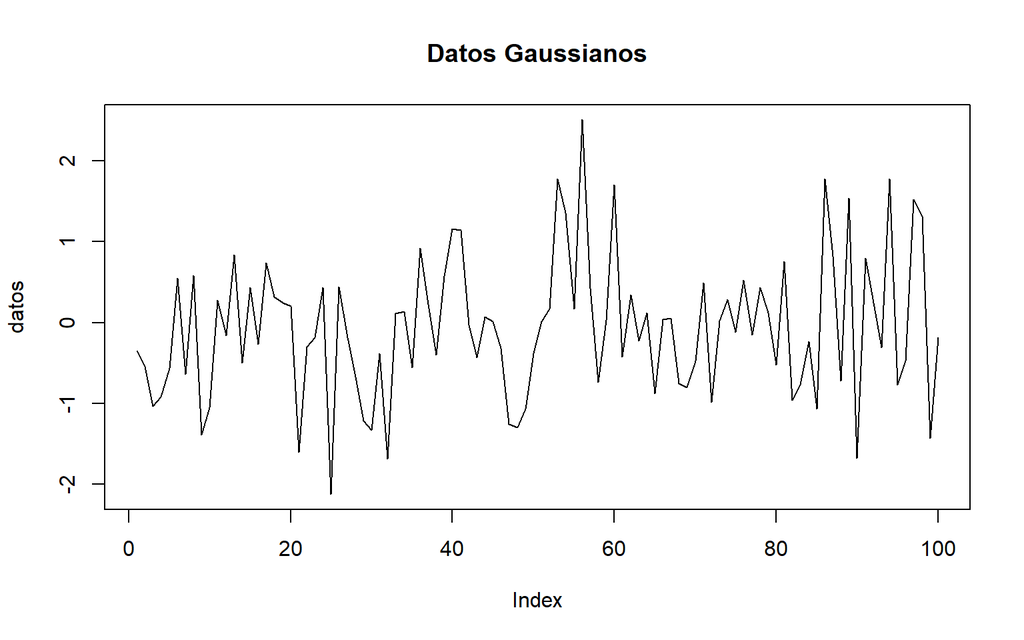

```r
datos <- rnorm(100,mean=0, sd=1)
plot(datos, type="l", main="Datos Gaussianos")
```

Existen muchas otras distribuciones continuas y el objetivo de ellas es adecuar nuestros datos a una de ellas con el objetivo de simular situaciones con valores tomados de ellas.

### Tarea

Investigar las siguientes distribuciones continuas de probabilidad (pueden incorporar el código en `R` que las genera aunque es opcional).

## Distribución uniforme continua.

La distribución uniforme continua modela la probabilidad de que una variable aleatoria tome cualquier valor dentro de un intervalo específico con igual probabilidad. La función en R para la distribución uniforme continua es dunif(), y se utiliza para calcular la función de densidad de probabilidad (PDF). Además, puedes usar punif() para calcular la función de distribución acumulativa (CDF), runif() para generar números aleatorios que sigan una distribución uniforme continua y qunif() para obtener los cuantiles.

Por ejemplo:

```r
# Parámetros de la distribución uniforme continua
rango_inferior <- 2  # Valor mínimo del intervalo
rango_superior <- 5  # Valor máximo del intervalo

# PDF: Probabilidad de que la variable aleatoria esté en el intervalo [2, 5]
probabilidad <- dunif(3, min = rango_inferior, max = rango_superior)

# CDF: Probabilidad acumulativa de que la variable aleatoria sea menor o igual a 3
prob_acumulativa <- punif(3, min = rango_inferior, max = rango_superior)

# Generar números aleatorios que sigan una distribución uniforme continua
num_aleatorio <- runif(1, min = rango_inferior, max = rango_superior)

# Calcular cuantiles de la distribución uniforme continua
cuantil_95 <- qunif(0.95, min = rango_inferior, max = rango_superior)

# Imprimir resultados
cat("Probabilidad de que la variable aleatoria esté en el intervalo [2, 5]:", probabilidad, "\n")
```

```
## Probabilidad de que la variable aleatoria esté en el intervalo [2, 5]: 0.3333333
```

```r
cat("Probabilidad acumulativa hasta 3:", prob_acumulativa, "\n")
```

```
## Probabilidad acumulativa hasta 3: 0.3333333
```

```r
cat("Número aleatorio generado:", num_aleatorio, "\n")
```

```
## Número aleatorio generado: 4.073997
```

```r
cat("Cuantil al 95%:", cuantil_95, "\n")
```

```
## Cuantil al 95%: 4.85
```

## Distribución exponencial.

La distribución exponencial modela el tiempo entre eventos en un proceso de Poisson, donde los eventos ocurren de manera continua e independiente a una tasa constante. La distribución exponencial tiene un parámetro λ (lambda), que es la tasa de ocurrencia de eventos por unidad de tiempo. En R, la función para la distribución exponencial es dexp(), y se utiliza para calcular la función de densidad de probabilidad (PDF). Además, puedes usar pexp() para calcular la función de distribución acumulativa (CDF), rexp() para generar números aleatorios que sigan una distribución exponencial y qexp() para obtener los cuantiles.

por ejemplo:

upongamos que queremos modelar el tiempo hasta que ocurra un evento, y la tasa de ocurrencia de eventos es de 0.5 eventos por unidad de tiempo. Aquí está cómo lo haríamos en R Studio:

```r
# Parámetros de la distribución exponencial
tasa_ocurrencia <- 0.5  # Tasa de ocurrencia de eventos por unidad de tiempo

# PDF: Probabilidad de que el tiempo hasta el evento sea igual a 2 unidades de tiempo
probabilidad <- dexp(2, rate = tasa_ocurrencia)

# CDF: Probabilidad acumulativa de que el tiempo hasta el evento sea menor o igual a 2 unidades de tiempo
prob_acumulativa <- pexp(2, rate = tasa_ocurrencia)

# Generar números aleatorios que sigan una distribución exponencial
num_aleatorio <- rexp(1, rate = tasa_ocurrencia)

# Calcular cuantiles de la distribución exponencial
cuantil_95 <- qexp(0.95, rate = tasa_ocurrencia)

# Imprimir resultados
cat("Probabilidad de que el tiempo hasta el evento sea igual a 2 unidades de tiempo:", probabilidad, "\n")
```

```
## Probabilidad de que el tiempo hasta el evento sea igual a 2 unidades de tiempo: 0.1839397
```

```r
cat("Probabilidad acumulativa hasta 2 unidades de tiempo:", prob_acumulativa, "\n")
```

```
## Probabilidad acumulativa hasta 2 unidades de tiempo: 0.6321206
```

```r
cat("Número aleatorio generado:", num_aleatorio, "\n")
```

```
## Número aleatorio generado: 1.517133
```

```r
cat("Cuantil al 95%:", cuantil_95, "\n")
```

```
## Cuantil al 95%: 5.991465
```

## Distribución Rayleigh

La distribución Rayleigh es una distribución continua que se utiliza comúnmente para modelar la magnitud de la componente horizontal de la velocidad del viento o para describir la distribución de la amplitud de una onda electromagnética en comunicaciones inalámbricas. En R Studio, puedes trabajar con la distribución Rayleigh utilizando funciones específicas.

En R, la función para la distribución Rayleigh es drayleigh(), y se utiliza para calcular la función de densidad de probabilidad (PDF). Además, puedes usar prayleigh() para calcular la función de distribución acumulativa (CDF), qrayleigh() para obtener cuantiles y rrayleigh() para generar números aleatorios que sigan una distribución Rayleigh.

Resumen: En R, la función para la distribución Rayleigh es drayleigh(), y se utiliza para calcular la función de densidad de probabilidad (PDF). Además, puedes usar prayleigh() para calcular la función de distribución acumulativa (CDF), qrayleigh() para obtener cuantiles y rrayleigh() para generar números aleatorios que sigan una distribución Rayleigh.

## Distribución Gamma.

La distribución gamma es una familia de distribuciones de probabilidad continuas que generaliza varias otras distribuciones, como la distribución exponencial, la distribución chi-cuadrado y la distribución Erlang. La distribución gamma se utiliza en diversos campos, incluyendo estadísticas, física, biología y finanzas.

En R, la función para la distribución gamma es dgamma(), y se utiliza para calcular la función de densidad de probabilidad (PDF). Además, puedes usar pgamma() para calcular la función de distribución acumulativa (CDF), rgamma() para generar números aleatorios que sigan una distribución gamma y qgamma() para obtener cuantiles.

Por ejemplo:

Supongamos que queremos modelar el tiempo que tarda un proceso en completarse, y que este tiempo sigue una distribución gamma con parámetros de forma **(shape)2** y tasa **(rate)0.5**. Aqui esta como lo hariamos en R Studio.

```r
# Parámetros de la distribución gamma
forma <- 2  # Parámetro de forma (shape) de la distribución gamma
tasa <- 0.5  # Parámetro de tasa (rate) de la distribución gamma

# PDF: Probabilidad de que el tiempo de completar el proceso sea igual a 3 unidades
probabilidad <- dgamma(3, shape = forma, rate = tasa)

# CDF: Probabilidad acumulativa de que el tiempo sea menor o igual a 3 unidades
prob_acumulativa <- pgamma(3, shape = forma, rate = tasa)

# Generar números aleatorios que sigan una distribución gamma
num_aleatorio <- rgamma(1, shape = forma, rate = tasa)

# Calcular cuantiles de la distribución gamma
cuantil_95 <- qgamma(0.95, shape = forma, rate = tasa)

# Imprimir resultados
cat("Probabilidad de que el tiempo de completar el proceso sea igual a 3 unidades:", probabilidad, "\n")
```

```
## Probabilidad de que el tiempo de completar el proceso sea igual a 3 unidades: 0.1673476
```

```r
cat("Probabilidad acumulativa hasta 3 unidades:", prob_acumulativa, "\n")
```

```
## Probabilidad acumulativa hasta 3 unidades: 0.4421746
```

```r
cat("Número aleatorio generado:", num_aleatorio, "\n")
```

```
## Número aleatorio generado: 2.63098
```

```r
cat("Cuantil al 95%:", cuantil_95, "\n")
```

```
## Cuantil al 95%: 9.487729
```

La tarea se debe entregar el día Miércoles 18 de octubre de 2023. Atte. Dr. Julio César Ramírez Pacheco.